# Predicting White-throated Sparrow Sex by Wing Chord Length

Daniel Redwine

2023-10-02

# Sex and Wing Chord Length

Previously the significant difference in wing chord length between males and females has been demonstrated. A GLM with Binomial distribution will be used to demonstrate if wing chord length can be used to predict sex. First we will visualize the raw data. The factors male and female have been transformed to values of 1 and 0 respectively.

[interactive chart not shown]

# Modelling Sex by Wing Chord Length

First we will visualize the data using geom_smooth with glm method.

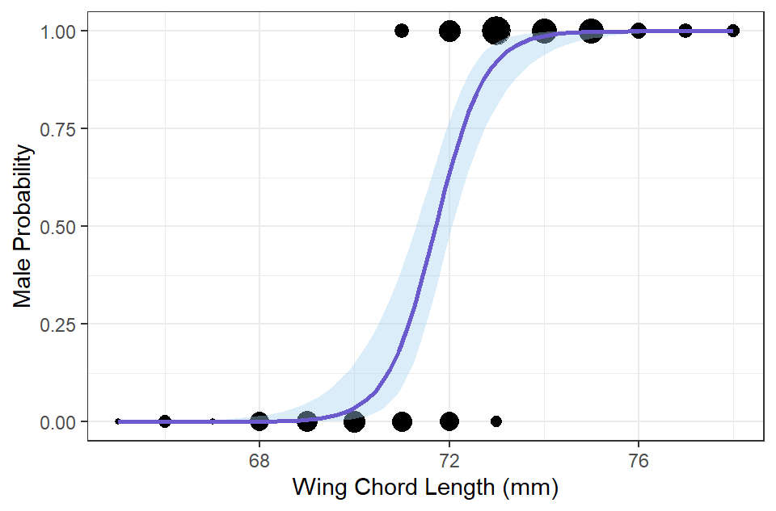

Figure 1. Probability of a White-throated Sparrow being male based on wing chord length. Points at 1 and 0 represent male and female wing chord measurements respectively while the line represents probability of a given measurement belonging to a male bird

Next we will create the model, a GLM with binomial distribution with a predictor of wing chord length for the response of sex.

```
##
## Call:  glm(formula = PCRsex ~ Wing, family = binomial(link = "logit"),
##     data = wing_sex_clean)
##
## Coefficients:
## (Intercept)         Wing
##    -138.222        1.927
##
## Degrees of Freedom: 134 Total (i.e. Null);  133 Residual
## Null Deviance:       180.9
## Residual Deviance: 58.28     AIC: 62.28
```

We will then check for overdispertion using library arm.

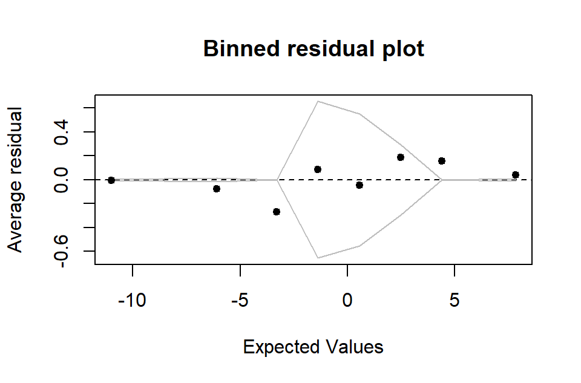

# Interpreting the Model

To interpret results we will use coef and confint.

```
## (Intercept)        Wing
##  -138.22157     1.92745
```

The coefficient for wing is 1.927. Using the divide by four method each 1mm increase in wing chord length leads to 48.2% increase in probability that a bird is a male.

```
##                   2.5 %     97.5 %
## (Intercept) -201.979668 -93.058387
## Wing           1.299471   2.814001
```

Here we can see the confidence intervals.

```
##
## Call:
## glm(formula = PCRsex ~ Wing, family = binomial(link = "logit"),
##     data = wing_sex_clean)
##
## Coefficients:
##              Estimate Std. Error z value Pr(>|z|)
## (Intercept) -138.2216    27.3050  -5.062 4.15e-07 ***
## Wing           1.9275     0.3797   5.077 3.84e-07 ***
## ---
## Signif. codes:  0 '***' 0.001 '**' 0.01 '*' 0.05 '.' 0.1 ' ' 1
##
## (Dispersion parameter for binomial family taken to be 1)
##
##     Null deviance: 180.871  on 134  degrees of freedom
## Residual deviance:  58.277  on 133  degrees of freedom
## AIC: 62.277
##
## Number of Fisher Scoring iterations: 7
```

Summary of the model predicting sex by wing chord length.